# Ο Μαθηματικός Αριθμός της Ομορφιάς

Κουμουνδούρος Ιωάννης

20 Οκτωβρίου 2025

Περίληψη

Ανακαλύψτε τον Χρυσό Λόγο (Φ≈1.618), τον μυστηριώδη μαθηματικό αριθμό που κρύβεται πίσω από την αίσθηση της αρμονίας και της ομορφιάς στη φύση και την τέχνη. Από τον τρόπο που ορίζεται μαθηματικά (ως η τέλεια αναλογία μεταξύ δύο μεγεθών), τη στενή του σχέση με τη Σειρά Fibonacci που καθορίζει τη διάταξη σπόρων στους ηλίανθους και τα σχήματα των κελυφών Ναυτίλου, μέχρι την υποτιθέμενη χρήση του στις διαστάσεις του Παρθενώνα και στα έργα του Λεονάρντο ντα Βίντσι, ο Φ αποδεικνύει ότι τα Μαθηματικά δεν είναι απλά ασκήσεις, αλλά η κρυφή γλώσσα της αισθητικής ισορροπίας που διαμορφώνει τον κόσμο γύρω μας και το σύγχρονο design.

Πόσες φορές έχουμε σταθεί μπροστά σε ένα έργο τέχνης, ένα επιβλητικό κτίριο ή ακόμα και σε ένα λουλούδι και αναφωνήσαμε: “Τι ομορφιά, τι αρμονία!” Πώς εξηγείται όμως αυτή η καθολική αίσθηση της τελειότητας; Είναι η ομορφιά απλώς θέμα γούστου, ή μήπως κρύβεται πίσω της μια αυστηρή, μαθηματική συνταγή;

Αναρωτηθήκατε ποτέ αν υπάρχει ένας “τέλειος” αριθμός που να καθορίζει αυτήν ακριβώς την αίσθηση της ισορροπίας; Καλώς ήρθατε στον κόσμο του **Χρυσού Λόγου**, ενός παράξενου και πανταχού παρόντα μαθηματικού αριθμού, γνωστού ως **Φ** (Φι).

Ο Φ, του οποίου η τιμή είναι περίπου **1.618**, δεν είναι απλώς ένας αριθμός. Είναι ένα κλειδί που ξεκλειδώνει τις μυστικές αναλογίες της φύσης, της αρχιτεκτονικής, της τέχνης και ακόμα και του σύγχρονου design. Από τους αρχαίους Έλληνες φιλοσόφους που τον χρησιμοποίησαν στον Παρθενώνα, μέχρι τον Λεονάρντο ντα Βίντσι και την ομορφιά που κρύβεται στη σπείρα ενός κελύφους

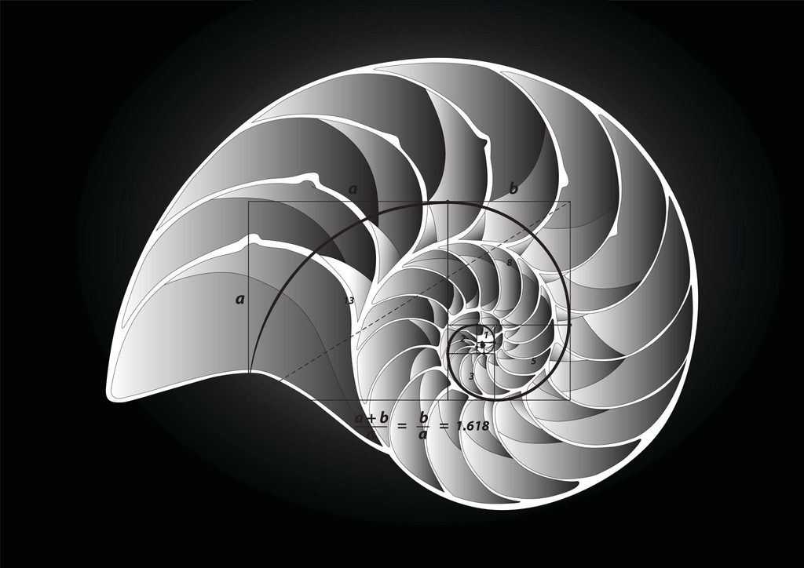

ο Χρυσός Λόγος μας αποκαλύπτει ότι τα Μαθηματικά είναι πολύ πιο ζωντανά και συναρπαστικά απ’ ό,τι φανταζόμαστε.

Ελάτε να εξερευνήσουμε πώς ένας και μόνο αριθμός μπορεί να είναι η ρίζα όλης της ομορφιάς γύρω μας!

### 1. Τι είναι ο Χρυσός Λόγος;

Ο Χρυσός Λόγος είναι ένας **άρητος αριθμός** (ένας αριθμός με άπειρα μη επαναλαμβανόμενα δεκαδικά ψηφία) που ισούται περίπου με **$1.6180339887\dots$**

#### Ο Μαθηματικός Ορισμός

Φανταστείτε ότι έχετε ένα ευθύγραμμο τμήμα. Θέλετε να το χωρίσετε σε δύο άνισα μέρη, **A** (το μεγαλύτερο) και **B** (το μικρότερο), έτσι ώστε:

$$\frac{A}{B} = \frac{A+B}{A} =
\Phi$$

Με απλά λόγια: **Ο λόγος του μεγαλύτερου μέρους προς το μικρότερο είναι ίδιος με τον λόγο του ολόκληρου προς το μεγαλύτερο μέρος.** Αυτή η αναλογία θεωρήθηκε ιδανική από τους αρχαίους Έλληνες.

### 2. Η Σειρά Fibonacci: Ο “Ξάδερφος” του $\Phi$

Ο Χρυσός Λόγος είναι άρρηκτα συνδεδεμένος με μια από τις πιο διάσημες ακολουθίες στα μαθηματικά: τη **Σειρά Fibonacci**.

Η ακολουθία ξεκινά με $1$ και $1$, και κάθε επόμενος αριθμός είναι το άθροισμα των δύο προηγούμενων:

$$1, 1, 2, 3, 5, 8, 13, 21, 34, 55,
\dots$$

#### Η Σύνδεση

Όσο προχωράτε στη σειρά Fibonacci, **ο λόγος δύο διαδοχικών αριθμών πλησιάζει ολοένα και περισσότερο τον $\Phi$!**

- $\frac{5}{3} = 1.666\dots$
- $\frac{8}{5} = 1.6$
- $\frac{13}{8} = 1.625$
- $\frac{21}{13} = 1.615\dots$
- $\frac{34}{21} \approx 1.619\dots$

Αυτή η σχέση είναι το κλειδί για την εμφάνιση του $\Phi$ στη φύση.

### 3. Ο $\Phi$ Γύρω μας: Η Μαγεία της Φύσης

Ο Χρυσός Λόγος και οι αριθμοί Fibonacci εμφανίζονται σε πολλά μέρη της φύσης που αναπτύσσονται σε σπείρα (σπειροειδώς):

- **Ηλίανθος:** Οι σπόροι είναι τοποθετημένοι σε σπείρες. Ο αριθμός των σπειρών που τρέχουν δεξιόστροφα και αριστερόστροφα είναι σχεδόν πάντα δύο διαδοχικοί αριθμοί Fibonacci (π.χ., 34 και 55).
- **Κουκουνάρια:** Ομοίως, οι φολίδες ακολουθούν σπειροειδείς διατάξεις που αντιστοιχούν σε αριθμούς Fibonacci.
- **Κελύφη:** Το σχήμα των κελυφών, όπως του **Ναυτίλου**, ακολουθεί μια **λογαριθμική σπείρα** που βασίζεται στο Χρυσό Ορθογώνιο.

### 4. Από τον Παρθενώνα στο Design

Η χρήση του Χρυσού Λόγου επεκτάθηκε και στον ανθρώπινο πολιτισμό, καθώς θεωρήθηκε η πεμπτουσία της **αρμονίας** και της **ισορροπίας**:

- **Αρχαία Αρχιτεκτονική:** Πολλοί πιστεύουν ότι ο **Παρθενώνας** στην Αθήνα έχει διαστάσεις που προσεγγίζουν το **Χρυσό Ορθογώνιο** (ένα ορθογώνιο του οποίου οι πλευρές έχουν λόγο $\Phi$).
- **Τέχνη της Αναγέννησης:** Καλλιτέχνες όπως ο **Λεονάρντο ντα Βίντσι** χρησιμοποίησαν συνειδητά (ή ασυνείδητα) τον $\Phi$ για τη σύνθεση των έργων τους, όπως στον περίφημο **«Άνθρωπο του Βιτρούβιου»**.
- **Σύγχρονο Design:** Ακόμη και σήμερα, ο Χρυσός Λόγος χρησιμοποιείται σε λογότυπα (π.χ., Apple, Twitter) και στη διάταξη ιστοσελίδων (**web design**) για να δημιουργήσει μια αίσθηση αισθητικής ισορροπίας που είναι ευχάριστη στο μάτι.

### Συμπέρασμα: Πέρα από τις Ασκήσεις

Ο Χρυσός Λόγος μας αποδεικνύει ότι τα μαθηματικά δεν είναι μια αφηρημένη έννοια κλεισμένη σε βιβλία. Είναι **η γλώσσα με την οποία η φύση και ο άνθρωπος εκφράζουν την ομορφιά και την αρμονία**.

Την επόμενη φορά που θα δείτε έναν ηλίανθο ή θα σχεδιάσετε κάτι, θυμηθείτε: πίσω από την ομορφιά κρύβεται ένας μοναδικός, άρρητος αριθμός: ο **$1.618\dots$**

- **Δείτε επίσης:** Μπορείτε να τον βρείτε στα δάχτυλά σας; Μετρήστε τον λόγο του μήκους κάθε φάλαγγας! (Μια πρόκληση για τους αναγνώστες).